# wb_pd1

```python
import numpy as np
import pandas as pd
import seaborn as sns
import torch

from matplotlib import pyplot as plt
from matplotlib import animation
from sklearn.datasets import load_iris
from sklearn.model_selection import train_test_split
from sklearn.preprocessing import OneHotEncoder
```

## XOR generation

```python
np.random.seed(1)
n = 10000
X = np.random.uniform(-10,10, size=(n,2))
ones = np.where(X[:,[0]] * X[:,[1]] > 0)
Y = np.zeros((n,1))
Y[ones] = 1
xor = pd.DataFrame(np.hstack([X,Y]), columns=['x', 'y', 'class'])
xor['class1'] = [1 if cl == 1 else 0 for cl in xor['class']]
xor['class0'] = [1 if cl == 0 else 0 for cl in xor['class']]
xor
```

|  | x | y | class | class1 | class0 |
| --- | --- | --- | --- | --- | --- |
| 0 | -1.659560 | 4.406490 | 0.0 | 0 | 1 |
| 1 | -9.997713 | -3.953349 | 1.0 | 1 | 0 |
| 2 | -7.064882 | -8.153228 | 1.0 | 1 | 0 |
| 3 | -6.274796 | -3.088785 | 1.0 | 1 | 0 |
| 4 | -2.064651 | 0.776335 | 0.0 | 0 | 1 |
| ... | ... | ... | ... | ... | ... |
| 9995 | 0.307447 | 6.498891 | 1.0 | 1 | 0 |
| 9996 | 4.539592 | 0.028959 | 1.0 | 1 | 0 |
| 9997 | -8.953078 | -6.501107 | 1.0 | 1 | 0 |
| 9998 | -0.932956 | -9.096221 | 1.0 | 1 | 0 |
| 9999 | 3.930562 | -4.007145 | 0.0 | 0 | 1 |

10000 rows × 5 columns

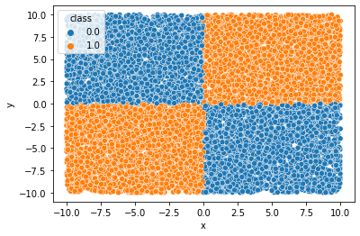

```python
sns.scatterplot(data=xor, x='x', y='y', hue='class')
```

```python
batch_size = 256

X_train, X_test, y_train, y_test = train_test_split(
    xor[['x','y']], xor[['class1', 'class0']] , test_size=0.33, random_state=42)

xor_train = torch.utils.data.TensorDataset(
    torch.tensor(X_train.values.astype(np.float32)),
    torch.tensor(y_train.values.astype(np.float32)))
xor_test = torch.utils.data.TensorDataset(
    torch.tensor(X_test.values.astype(np.float32)),
    torch.tensor(y_test.values.astype(np.float32)))


xor_dataloader_train = torch.utils.data.DataLoader(xor_train, batch_size, shuffle=True, num_workers=2)
xor_dataloader_test = torch.utils.data.DataLoader(xor_test, batch_size, shuffle=True, num_workers=2)
```

## Download Iris

```python
iris_x, iris_y = load_iris(return_X_y=True, as_frame=True)
```

```python
ohe = OneHotEncoder()
iris_y_encoded = ohe.fit_transform(pd.DataFrame(iris_y)).toarray()
```

```python
batch_size = 8

X_train, X_test, y_train, y_test = train_test_split(
    iris_x, iris_y_encoded , test_size=0.33, random_state=42)

iris_train = torch.utils.data.TensorDataset(
    torch.tensor(X_train.values.astype(np.float32)),
    torch.tensor(y_train.astype(np.float32)))
iris_test = torch.utils.data.TensorDataset(
    torch.tensor(X_test.values.astype(np.float32)),
    torch.tensor(y_test.astype(np.float32)))


iris_dataloader_train = torch.utils.data.DataLoader(iris_train, batch_size, shuffle=True, num_workers=2)
iris_dataloader_test = torch.utils.data.DataLoader(iris_test, batch_size, shuffle=True, num_workers=2)
```

## Train XOR neural network

```python
def calculate_error(y_hat, y): # 1 - accuracy
    return 1 - np.mean((torch.argmax(y_hat, dim=1, keepdim=True) - torch.argmax(y, dim=1, keepdim=True) == 0).numpy())
```

```python
xor_net = torch.nn.Sequential(
    torch.nn.Linear(2, 3),
    torch.nn.ReLU(),
    torch.nn.Linear(3,2),
    torch.nn.Softmax()
)

def init_weights(m):
    torch.manual_seed(123)
    if isinstance(m, torch.nn.Linear):
        torch.nn.init.normal_(m.weight, std=1)

xor_net.apply(init_weights)

learning_rate = 0.1
loss = torch.nn.CrossEntropyLoss(reduction='none')
optimizer = torch.optim.SGD(xor_net.parameters(), lr=learning_rate)
```

```python
losses = []
errors_train = []
errors_test = []
num_iter = 100


for epoch in range(num_iter):
    losses_iter = []
    errors_train_iter = []
    errors_test_iter = []

    for X, y in xor_dataloader_test:
        y_hat = xor_net(X)
        errors_test_iter += [calculate_error(y_hat, y)]


    for X, y in xor_dataloader_train:
        y_hat = xor_net(X)
        l = loss(y_hat, y)
        errors_train_iter +=  [calculate_error(y_hat, y)]
        optimizer.zero_grad()
        l.mean().backward()
        losses_iter += [l.mean().item()]
        optimizer.step()

    errors_train += [np.mean(errors_train_iter)]
    errors_test += [np.mean(errors_test_iter)]
    losses += [np.mean(losses_iter)]
```

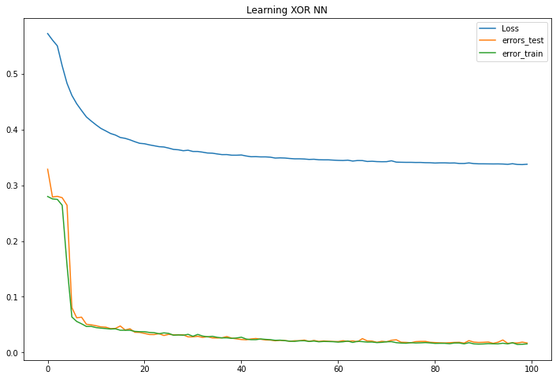

```python
plt.figure(figsize=(12, 8))
plt.plot(range(num_iter), losses)
plt.plot(range(num_iter), errors_test)
plt.plot(range(num_iter), errors_train)

plt.title("Learning XOR NN")
plt.legend(['Loss', 'errors_test', 'error_train'])
plt.show()
```

### Check accuracy for the test dataset

```python
errors_test =[]

for X, y in xor_dataloader_test:
    y_hat = xor_net(X)
    errors_test += [calculate_error(y_hat, y)]

np.mean(errors_test)
```

```
0.018777412280701757
```

## Train Iris network

```python
iris_net = torch.nn.Sequential(
    torch.nn.Linear(4, 50),
    torch.nn.ReLU(),
    torch.nn.Linear(50,25),
    torch.nn.ReLU(),
    torch.nn.Linear(25,3),
    torch.nn.Softmax()
)

def init_weights(m):
    if isinstance(m, torch.nn.Linear):
        torch.nn.init.normal_(m.weight, std=0.2)

iris_net.apply(init_weights)

learning_rate = 0.01
loss = torch.nn.CrossEntropyLoss(reduction='none')
optimizer = torch.optim.SGD(iris_net.parameters(), lr=learning_rate)
```

```python
losses = []
errors_train = []
errors_test = []
num_iter = 100


for epoch in range(num_iter):
    losses_iter = []
    errors_train_iter = []
    errors_test_iter = []

    for X, y in iris_dataloader_test:
        y_hat = iris_net(X)
        errors_test_iter += [calculate_error(y_hat, y)]


    for X, y in iris_dataloader_train:
        y_hat = iris_net(X)
        l = loss(y_hat, y)
        errors_train_iter +=  [calculate_error(y_hat, y)]
        optimizer.zero_grad()
        l.mean().backward()
        losses_iter += [l.mean().item()]
        optimizer.step()

    errors_train += [np.mean(errors_train_iter)]
    errors_test += [np.mean(errors_test_iter)]
    losses += [np.mean(losses_iter)]
```

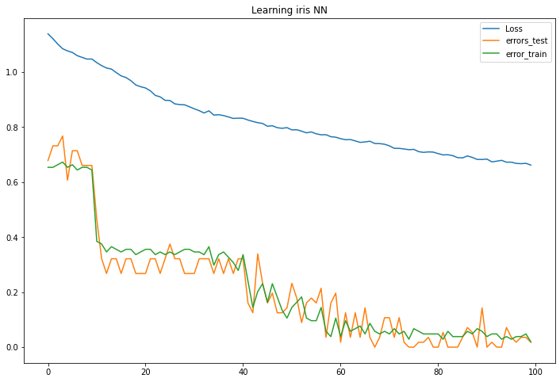

```python
import matplotlib.pyplot as plt
plt.figure(figsize=(12, 8))
plt.plot(range(num_iter), losses)
plt.plot(range(num_iter), errors_test)
plt.plot(range(num_iter), errors_train)

plt.title("Learning iris NN")
plt.legend(['Loss', 'errors_test', 'error_train'])
plt.show()
```

```python
errors_test =[]

for X, y in iris_dataloader_test:
    y_hat = iris_net(X)
    errors_test += [calculate_error(y_hat, y)]

np.mean(errors_test)
```

```
0.10714285714285714
```

## Architectures comparison

### XOR Dataset (2 inputs, 2 outputs)

- [2, 3, 2]
- [2, 15, 2]
- [2, 100, 2]
- [2, 2, 2, 2]
- [2, 10, 5, 2]

```python
def init_weights(m, std=1):
    if isinstance(m, torch.nn.Linear):
        torch.nn.init.normal_(m.weight, std=1)

def train_nn(nnet, dataloader_test, dataloader_train, lr=0.1, n_epochs = 40, init_std=1):
    torch.manual_seed(0)
    nnet.apply(lambda x: init_weights(x, init_std))
    loss = torch.nn.CrossEntropyLoss(reduction='none')
    optimizer = torch.optim.SGD(nnet.parameters(), lr=lr)

    losses = []
    errors_train = []
    errors_test = []

    for epoch in range(n_epochs):
        losses_iter = []
        errors_train_iter = []
        errors_test_iter = []

        for X, y in dataloader_test:
            y_hat = nnet(X)
            errors_test_iter += [calculate_error(y_hat, y)]


        for X, y in dataloader_train:
            y_hat = nnet(X)
            l = loss(y_hat, y)
            errors_train_iter +=  [calculate_error(y_hat, y)]
            optimizer.zero_grad()
            l.mean().backward()
            losses_iter += [l.mean().item()]
            optimizer.step()

        errors_train += [np.mean(errors_train_iter)]
        errors_test += [np.mean(errors_test_iter)]
        losses += [np.mean(losses_iter)]
    return {'nnet':nnet, 'e_train':errors_train, 'e_test':errors_test, 'loss':losses}
```

```python
xor_nets = [
    torch.nn.Sequential(
        torch.nn.Linear(2, 3),
        torch.nn.ReLU(),
        torch.nn.Linear(3, 2),
        torch.nn.Softmax()),

    torch.nn.Sequential(
        torch.nn.Linear(2, 15),
        torch.nn.ReLU(),
        torch.nn.Linear(15, 2),
        torch.nn.Softmax()),

    torch.nn.Sequential(
        torch.nn.Linear(2, 100),
        torch.nn.ReLU(),
        torch.nn.Linear(100, 2),
        torch.nn.Softmax()),

    torch.nn.Sequential(
        torch.nn.Linear(2, 2),
        torch.nn.ReLU(),
        torch.nn.Linear(2, 2),
        torch.nn.ReLU(),
        torch.nn.Linear(2, 2),
        torch.nn.Softmax()),

    torch.nn.Sequential(
        torch.nn.Linear(2, 10),
        torch.nn.ReLU(),
        torch.nn.Linear(10, 5),
        torch.nn.ReLU(),
        torch.nn.Linear(5, 2),
        torch.nn.Softmax()),
]

nets_names = ['3', '15', '100', '2-2', '10-5']
for net, name in zip(xor_nets, nets_names):
    net.name = name
```

```python
result = {}
for net in xor_nets:
    result[net.name] = train_nn(net, xor_dataloader_test, xor_dataloader_train, n_epochs=100)
```

```python
losses = pd.DataFrame([result[name]['loss'] for name in nets_names]).T
es_test = pd.DataFrame([result[name]['e_test'] for name in nets_names]).T
es_train = pd.DataFrame([result[name]['e_train'] for name in nets_names]).T
losses.columns, es_test.columns, es_train.columns =  [nets_names] * 3
losses.rename_axis('architecture', axis=1, inplace=True)
es_test.rename_axis('architecture', axis=1, inplace=True)
es_train.rename_axis('architecture', axis=1, inplace=True)

losses.rename_axis('epoch', axis=0, inplace=True)
es_test.rename_axis('epoch', axis=0, inplace=True)
es_train.rename_axis('epoch', axis=0, inplace=True)
```

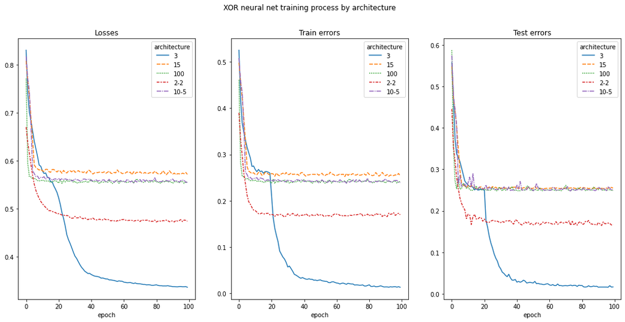

```python
fig, ax = plt.subplots(1,3)

fig.set_size_inches(18,8)
fig.suptitle("XOR neural net training process by architecture")
sns.lineplot(data=losses, ax=ax[0])
ax[0].set_title('Losses')
plt.legend(nets_names)

sns.lineplot(data=es_train, ax=ax[1])
ax[1].set_title('Train errors')

sns.lineplot(data=es_test, ax=ax[2])
ax[2].set_title('Test errors')
plt.show()
```

- We can see that every architecture has a decreasing loss.
- The best fitted is the simplest network (with `3` neurons).
- Test errors are more rugged, but even larger networks seem not to be overfitting. This may be a result of uniformly distributed artificial data.
- Larger nets must have fallen into local minimum.

### Iris dataset (4 inputs, 3 outputs)

- [4, 50, 25, 3]
- [4, 5, 3]
- [4, 100, 3]
- [4, 10, 5, 3]
- [4, 10, 10, 10, 3]

```python
iris_nets = [
    torch.nn.Sequential(
        torch.nn.Linear(4, 50),
        torch.nn.ReLU(),
        torch.nn.Linear(50,25),
        torch.nn.ReLU(),
        torch.nn.Linear(25,3),
        torch.nn.Softmax()
    ),
    torch.nn.Sequential(
        torch.nn.Linear(4, 5),
        torch.nn.ReLU(),
        torch.nn.Linear(5,3),
        torch.nn.Softmax()
    ),
    torch.nn.Sequential(
        torch.nn.Linear(4, 100),
        torch.nn.ReLU(),
        torch.nn.Linear(100,3),
        torch.nn.Softmax()
    ),
    torch.nn.Sequential(
        torch.nn.Linear(4, 10),
        torch.nn.ReLU(),
        torch.nn.Linear(10,5),
        torch.nn.ReLU(),
        torch.nn.Linear(5,3),
        torch.nn.Softmax()
    ),
    torch.nn.Sequential(
        torch.nn.Linear(4, 10),
        torch.nn.ReLU(),
        torch.nn.Linear(10,10),
        torch.nn.ReLU(),
        torch.nn.Linear(10,10),
        torch.nn.ReLU(),
        torch.nn.Linear(10,3),
        torch.nn.Softmax()
    )]
iris_nets_names = ['50-25', '5', '100', '10-5', '10-10-10']

for net, name in zip(iris_nets, iris_nets_names):
    net.name = name
```

```python
result_iris = {}
for net in iris_nets:
    result_iris[net.name] = train_nn(net, iris_dataloader_test, iris_dataloader_train, n_epochs=100, lr=0.01, init_std=0.1)
```

```python
losses = pd.DataFrame([result_iris[name]['loss'] for name in iris_nets_names]).T
es_test = pd.DataFrame([result_iris[name]['e_test'] for name in iris_nets_names]).T
es_train = pd.DataFrame([result_iris[name]['e_train'] for name in iris_nets_names]).T
losses.columns, es_test.columns, es_train.columns =  [iris_nets_names] * 3
losses.rename_axis('architecture', axis=1, inplace=True)
es_test.rename_axis('architecture', axis=1, inplace=True)
es_train.rename_axis('architecture', axis=1, inplace=True)

losses.rename_axis('epoch', axis=0, inplace=True)
es_test.rename_axis('epoch', axis=0, inplace=True)
es_train.rename_axis('epoch', axis=0, inplace=True)
```

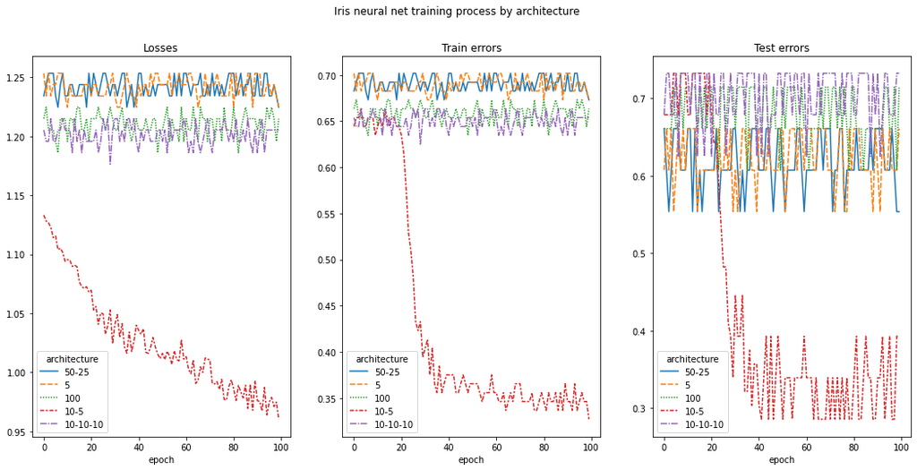

```python
fig, ax = plt.subplots(1,3)

fig.set_size_inches(18,8)
fig.suptitle("Iris neural net training process by architecture")
sns.lineplot(data=losses, ax=ax[0])
ax[0].set_title('Losses')
plt.legend(nets_names)

sns.lineplot(data=es_train, ax=ax[1])
ax[1].set_title('Train errors')

sns.lineplot(data=es_test, ax=ax[2])
ax[2].set_title('Test errors')
plt.show()
```

Prevoius plot is very noisy, let's try plotting only every 5th epoch.

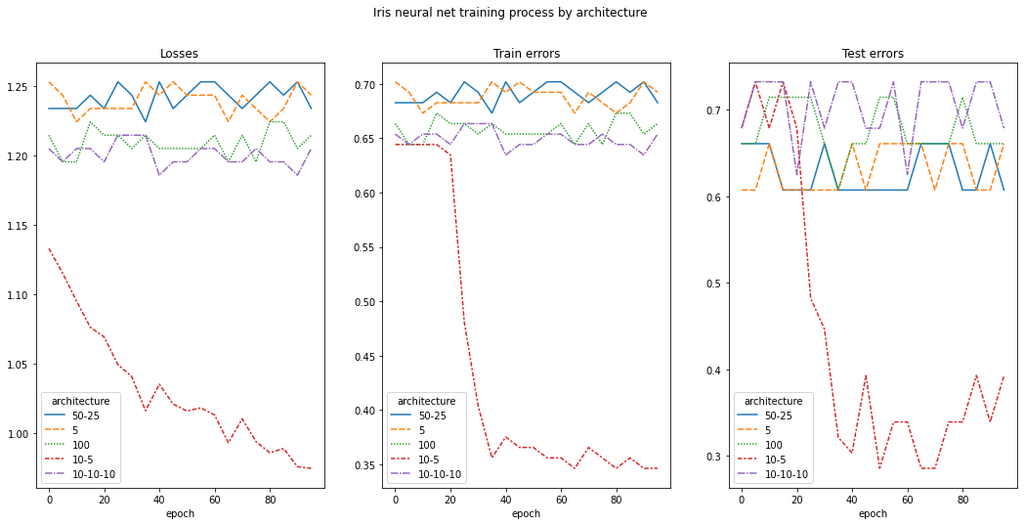

```python
fig, ax = plt.subplots(1,3)

fig.set_size_inches(18,8)
fig.suptitle("Iris neural net training process by architecture")
sns.lineplot(data=losses.iloc[::5,:], ax=ax[0])
ax[0].set_title('Losses')
plt.legend(nets_names)

sns.lineplot(data=es_train.iloc[::5,:], ax=ax[1])
ax[1].set_title('Train errors')

sns.lineplot(data=es_test.iloc[::5,:], ax=ax[2])
ax[2].set_title('Test errors')
plt.show()
```

- Only small 2 layer architecture (`10-5`) has a decreasing loss and errors.
- Other architectures don't learn.
- Test errors of `10-5` architecture increase after 70-th epoch. It could indicate overfitting.

## Learning rate comparison

```python
def reset_net(net):
    torch.manual_seed(0)
    net.apply(init_weights)

def train_net_lr(net, learning_rate):
    loss = torch.nn.CrossEntropyLoss(reduction='none')
    optimizer = torch.optim.SGD(net.parameters(), lr=learning_rate)
    losses = []
    errors_train = []
    errors_test = []
    num_iter = 100


    for epoch in range(num_iter):
        losses_iter = []
        errors_train_iter = []
        errors_test_iter = []

        for X, y in xor_dataloader_test:
            y_hat = net(X)
            errors_test_iter += [calculate_error(y_hat, y)]


        for X, y in xor_dataloader_train:
            y_hat = net(X)
            l = loss(y_hat, y)
            errors_train_iter +=  [calculate_error(y_hat, y)]
            optimizer.zero_grad()
            l.mean().backward()
            losses_iter += [l.mean().item()]
            optimizer.step()

        errors_train += [np.mean(errors_train_iter)]
        errors_test += [np.mean(errors_test_iter)]
        losses += [np.mean(losses_iter)]

    return {'lr':learning_rate, 'loss':losses, 'es_test':errors_test, 'es_train':errors_train}
```

```python
result_lr = {}
learning_rates = [0.0001, 0.001, 0.01, 0.1, 1]
for lr in learning_rates:
    reset_net(xor_net)
    result_lr[lr] = train_net_lr(xor_net, lr)
```

```python
losses = pd.DataFrame([result_lr[lr]['loss'] for lr in learning_rates]).T
es_test = pd.DataFrame([result_lr[lr]['es_test'] for lr in learning_rates]).T
es_train = pd.DataFrame([result_lr[lr]['es_train'] for lr in learning_rates]).T
losses.columns = [str(lr) for lr in learning_rates]
es_test.columns = [str(lr) for lr in learning_rates]
es_train.columns =  [str(lr) for lr in learning_rates]
losses.rename_axis('learnig rate', axis=1, inplace=True)
es_test.rename_axis('learnig rate', axis=1, inplace=True)
es_train.rename_axis('learnig rate', axis=1, inplace=True)

losses.rename_axis('epoch', axis=0, inplace=True)
es_test.rename_axis('epoch', axis=0, inplace=True)
es_train.rename_axis('epoch', axis=0, inplace=True)
```

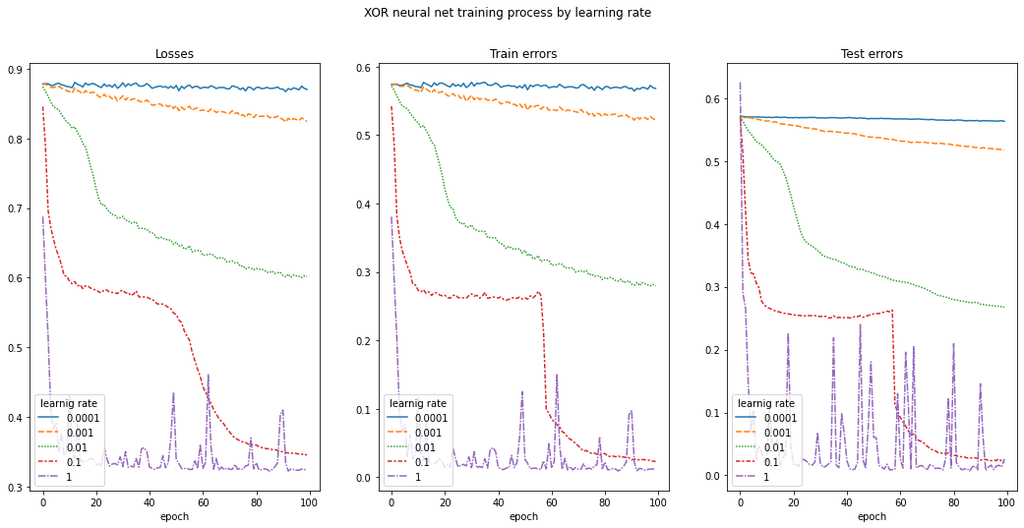

```python
fig, ax = plt.subplots(1,3)

fig.set_size_inches(18,8)
fig.suptitle("XOR neural net training process by learning rate")
sns.lineplot(data=losses, ax=ax[0])
ax[0].set_title('Losses')
plt.legend(nets_names)

sns.lineplot(data=es_train, ax=ax[1])
ax[1].set_title('Train errors')

sns.lineplot(data=es_test, ax=ax[2])
ax[2].set_title('Test errors')
plt.show()
```

- The bigger the learning_rate the faster network learns.
- Network doesn't learn with small learning_rate (0,0001).
- With large learning_rate (i.e 1) there is some chance for *overshooting* the minimum and increasing the loss and errors.

## Decision boundries animation

```python
learning_rate = 0.01
loss = torch.nn.CrossEntropyLoss(reduction='none')
optimizer = torch.optim.SGD(xor_net.parameters(), lr=learning_rate)
```

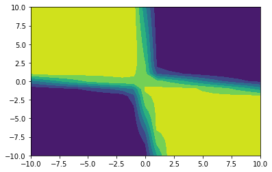

```python
"""
Matplotlib Animation Example

author: Jake Vanderplas
email: vanderplas@astro.washington.edu
website: http://jakevdp.github.com
license: BSD
Please feel free to use and modify this, but keep the above information. Thanks!
"""


# First set up the figure, the axis, and the plot element we want to animate
fig = plt.figure()
x = np.linspace(-10, 10, 21)
y = np.linspace(-10, 10, 21)
g = np.meshgrid(x, y, indexing='xy')
mesh = torch.tensor([(x,y) for x, y in zip(*(x.flat for x in g))], dtype=torch.float)
# reset NN
xor_net.apply(init_weights)

out = xor_net(X)
plt.contourf(x, y, out[:,1].detach().numpy().reshape(21,21))

# initialization function: plot the background of each frame
def init():
    plt.contourf(x, y, np.zeros(shape=(21,21)))

# animation function.  This is called sequentially
def animate(i):
    out = xor_net(mesh)
    for X, y_ in xor_dataloader_train:
        y_hat = xor_net(X)
        l = loss(y_hat, y_)
        optimizer.zero_grad()
        l.mean().backward()
        optimizer.step()
    plt.contourf(x, y, out[:,1].detach().numpy().reshape(21,21))

anim = animation.FuncAnimation(fig, animate, init_func=init,
                               frames=200, interval=20, blit=False)

# save the animation as an mp4.  This requires ffmpeg or mencoder to be
# installed.  The extra_args ensure that the x264 codec is used, so that
# the video can be embedded in html5.  You may need to adjust this for
# your system: for more information, see
# http://matplotlib.sourceforge.net/api/animation_api.html
anim.save('basic_animation.mp4', fps=30, extra_args=['-vcodec', 'libx264'])

plt.show()
```

```python
from IPython.display import Video

Video("basic_animation.mp4")
```

[video not shown]